# Clean Salty Soil Data

Irfan Ainuddin, Jessica Shippen, Olivia Lund

4/6/2020

```r
library(tidyverse)
library(kableExtra)
sd <- readRDS(file = "./data/clean_soil_data.rds")
```

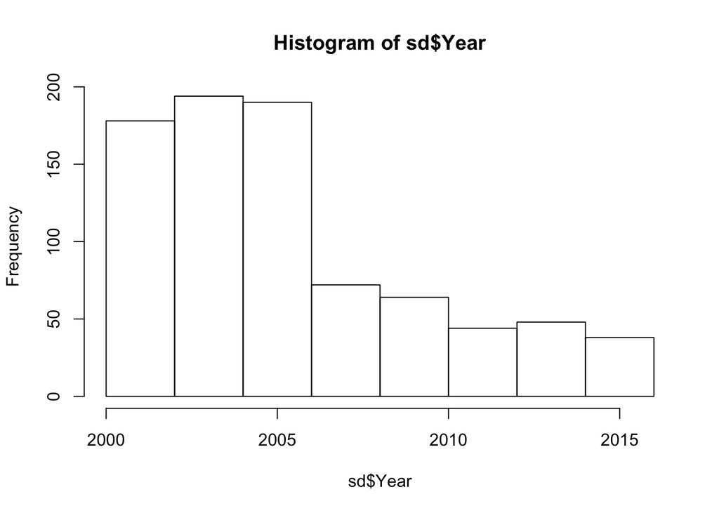

```r
hist(sd$Year)
```

Most of the data was collected 2000-2005.

## Calcium Saturation Percent (%)

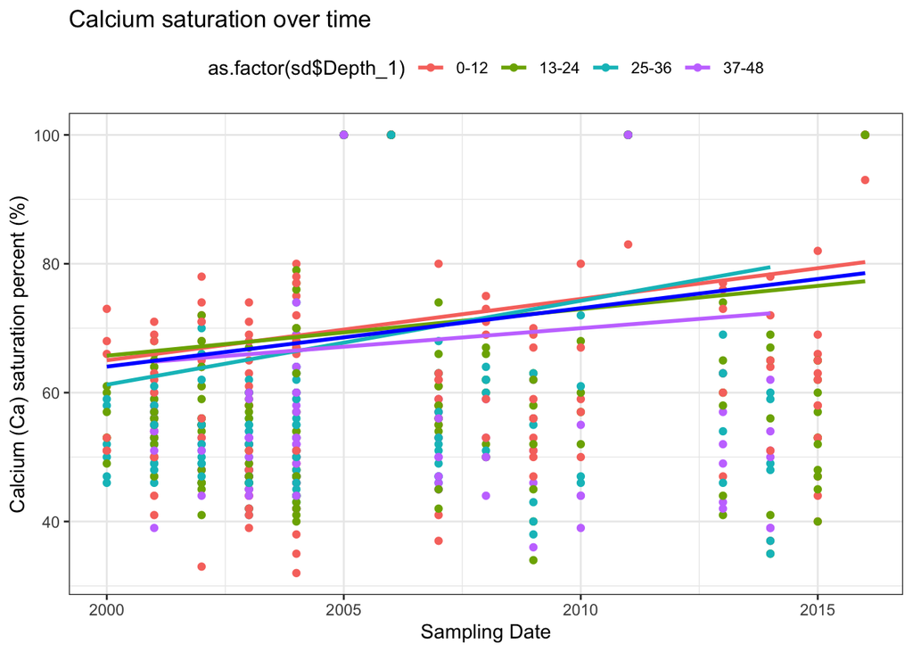

```r
ggplot(sd, aes(x=sd$Year, y=sd$Ca_Sat_pct, col=as.factor(sd$Depth_1))) +
            geom_point() + theme_bw() + theme(legend.position="top") +
            geom_smooth(se=FALSE, method="lm") +
            geom_smooth(aes(x=sd$Year, y=sd$Ca_Sat_pct), col="blue", se=FALSE, method='lm')+
            xlab("Sampling Date") +
            ylab("Calcium (Ca) saturation percent (%)") +
            ggtitle("Calcium saturation over time")
```

## Magnesium Saturation Percent (%)

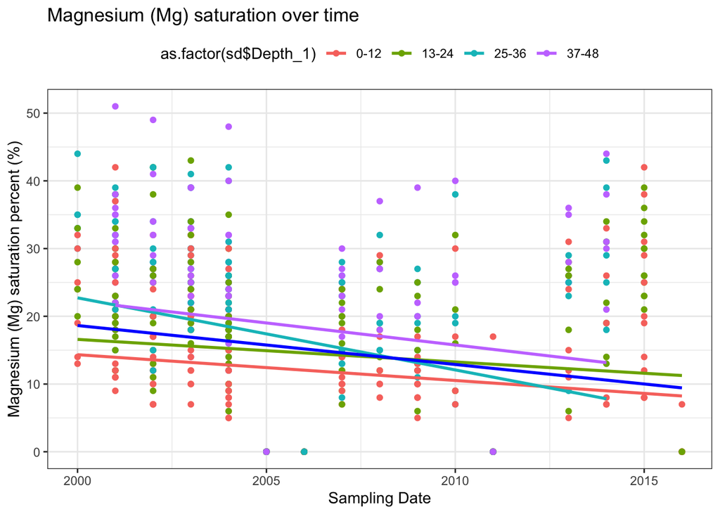

```r
ggplot(sd, aes(x=sd$Year, y=sd$Mg_Sat_pct, col=as.factor(sd$Depth_1))) +
            geom_point() + theme_bw() + theme(legend.position="top") +
            geom_smooth(se=FALSE, method="lm") +
            geom_smooth(aes(x=sd$Year, y=sd$Mg_Sat_pct), col="blue", se=FALSE, method='lm')+
            xlab("Sampling Date") +
            ylab("Magnesium (Mg) saturation percent (%)") +
            ggtitle("Magnesium (Mg) saturation over time")
```

Overall magnesium trend is decreasing at all depths.

## Sodium Saturation Percent (%)

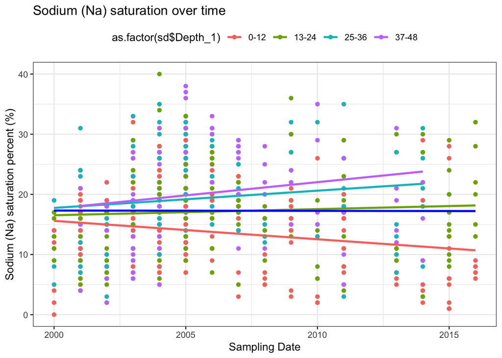

```r
#
ggplot(sd, aes(x=sd$Year, y=sd$Na_Sat_pct, col=as.factor(sd$Depth_1))) +
            geom_point() + theme_bw() + theme(legend.position="top") +
            geom_smooth(se=FALSE, method="lm") +
            geom_smooth(aes(x=sd$Year, y=sd$Na_Sat_pct), col="blue", se=FALSE, method='lm') +
            xlab("Sampling Date") +
            ylab("Sodium (Na) saturation percent (%)") +
            ggtitle("Sodium (Na) saturation over time")
```

```r
## irf: geom_smooth y changed from Mg_sat_pct  > Na_sat_pct
```

These trends suggest that sodium is leeching out of the top soil into the subsoil primarily in the two lower depth classes.

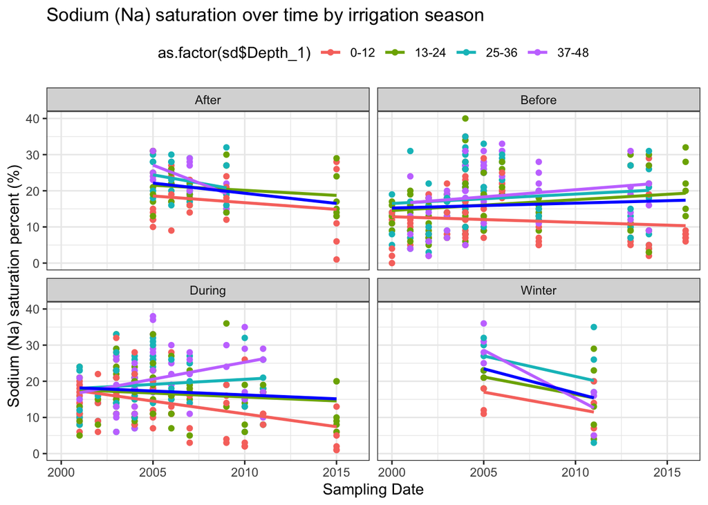

```r
## lets facet_wrap() by irrigation season
ggplot(sd, aes(x=sd$Year, y=sd$Na_Sat_pct, col=as.factor(sd$Depth_1))) +
            geom_point() + theme_bw() + theme(legend.position="top") +
            geom_smooth(se=FALSE, method="lm") +
            geom_smooth(aes(x=sd$Year, y=sd$Na_Sat_pct), col="blue", se=FALSE, method='lm') +
            facet_wrap(sd$Irr_season) +
            xlab("Sampling Date") +
            ylab("Sodium (Na) saturation percent (%)") +
            ggtitle("Sodium (Na) saturation over time by irrigation season")
```

In all irrigation seasons the sodium saturation percent is decreasing for the 0-12" depth class. The samples collected ‘Before’ the irrigation are most similar to the overall changes shown. When we look at changes in sodium levels after irrigation and during the winter we see a decreasing trend for all of the soil depth classes, which is reflecting the soluble nature of sodium moving or leaching out with water in the natural environment.

Slightly higher Na Sat Pct in deeper layers.

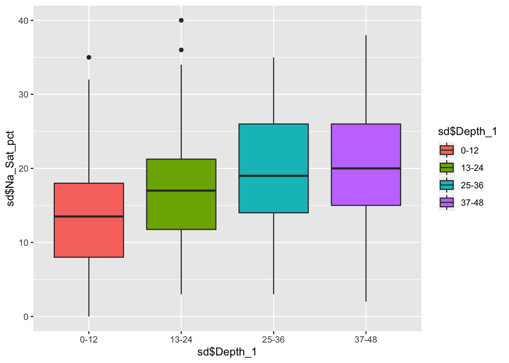

```r
ggplot(sd, aes(x=sd$Depth_1, y=sd$Na_Sat_pct, fill=sd$Depth_1)) + geom_boxplot()
```

## Exchangable Sodium (Na) Parts Per Million

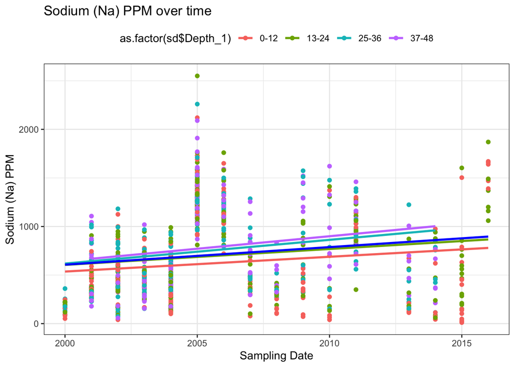

```r
ggplot(sd, aes(x=sd$Year, y=sd$ExchNa_ppm, col=as.factor(sd$Depth_1))) +
            geom_point() + theme_bw() + theme(legend.position="top") +
            geom_smooth(se=FALSE, method="lm") +
            geom_smooth(aes(x=sd$Year, y=sd$ExchNa_ppm), col="blue", se=FALSE, method='lm') +
            xlab("Sampling Date") +
            ylab("Sodium (Na) PPM") +
            ggtitle("Sodium (Na) PPM over time")
```

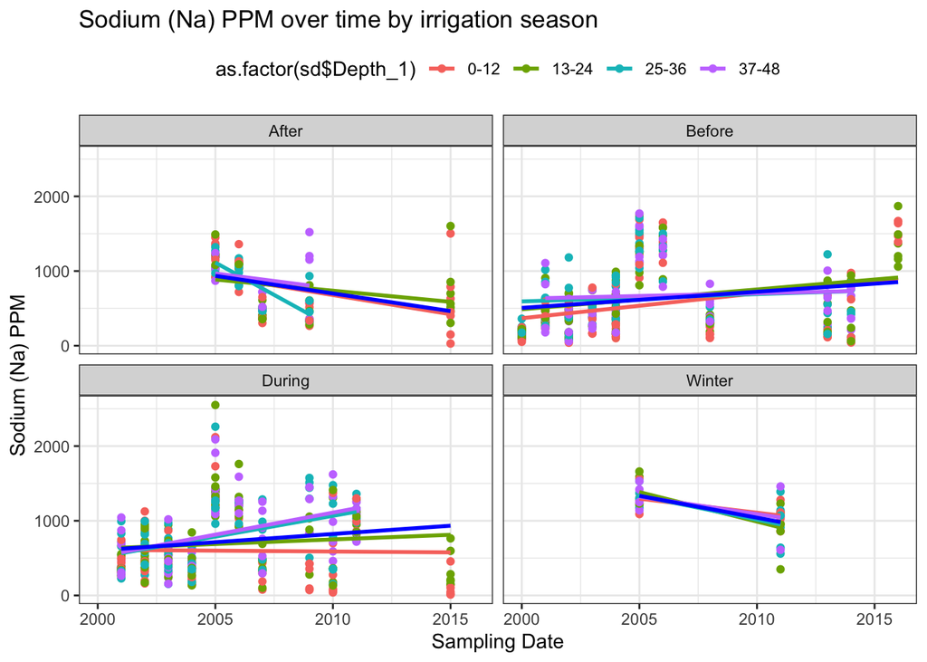

```r
## lets facet_wrap() by irrigation season
ggplot(sd, aes(x=sd$Year, y=sd$ExchNa_ppm, col=as.factor(sd$Depth_1))) +
            geom_point() + theme_bw() + theme(legend.position="top") +
            geom_smooth(se=FALSE, method="lm") +
            geom_smooth(aes(x=sd$Year, y=sd$ExchNa_ppm), col="blue", se=FALSE, method='lm') +
            facet_wrap(sd$Irr_season) +
            xlab("Sampling Date") +
            ylab("Sodium (Na) PPM") +
            ggtitle("Sodium (Na) PPM over time by irrigation season")
```

## Potassium Saturation Percent

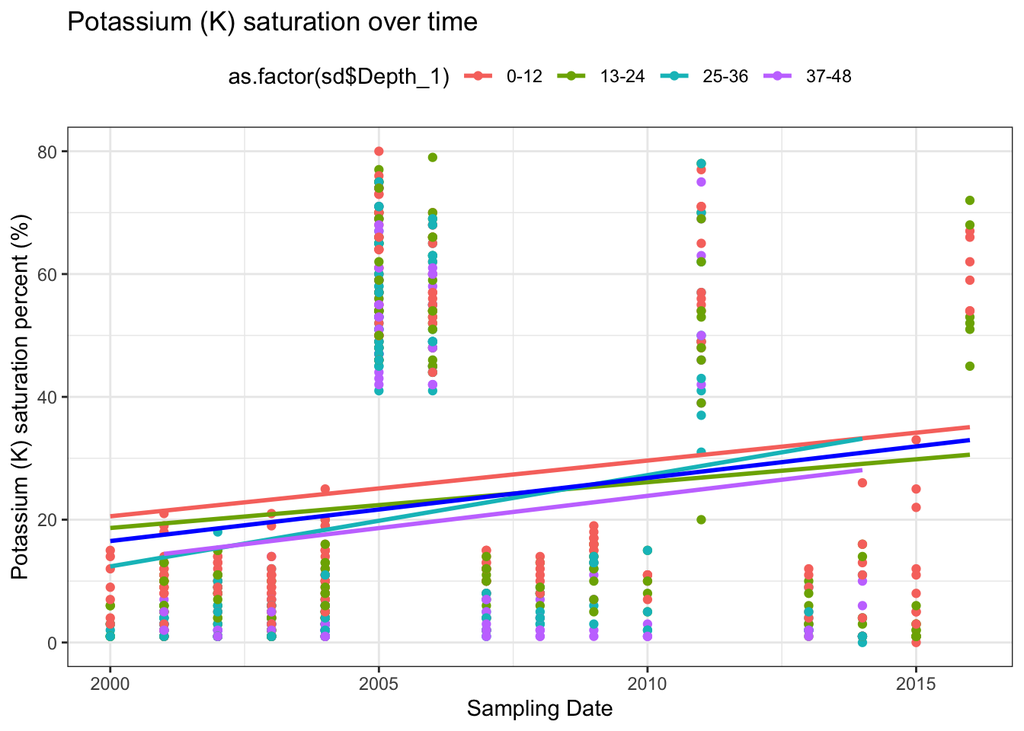

```r
ggplot(sd, aes(x=sd$Year, y=sd$K_Sat_pct, col=as.factor(sd$Depth_1))) +
            geom_point() + theme_bw() + theme(legend.position="top") +
            geom_smooth(se=FALSE, method="lm") +
            geom_smooth(aes(x=sd$Year, y=sd$K_Sat_pct), col="blue", se=FALSE, method='lm') +
            xlab("Sampling Date") +
            ylab("Potassium (K) saturation percent (%)") +
            ggtitle("Potassium (K) saturation over time")
```

Overall potassium seems to be increasing with a positive linear trend over time for all soil horizons (depth classes).

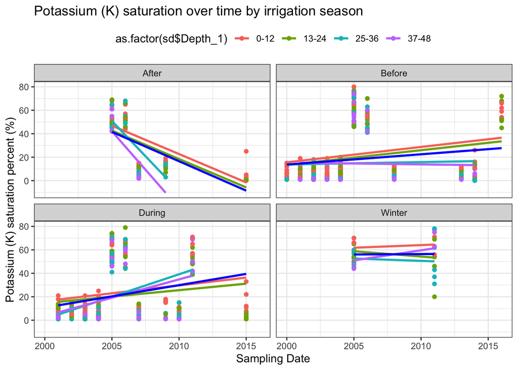

```r
## lets facet_wrap() by irrigation season
ggplot(sd, aes(x=sd$Year, y=sd$K_Sat_pct, col=as.factor(sd$Depth_1))) +
            geom_point() + theme_bw() + theme(legend.position="top") +
            geom_smooth(se=FALSE, method="lm") +
            geom_smooth(aes(x=sd$Year, y=sd$K_Sat_pct), col="blue", se=FALSE, method='lm') +
            facet_wrap(sd$Irr_season) +
            xlab("Sampling Date") +
            ylab("Potassium (K) saturation percent (%)") +
            ggtitle("Potassium (K) saturation over time by irrigation season")
```

```r
## not sure how to interpet all of this, i sort of think the winter sampling irragtion season doesnt make sense
```

## Exchangable Potassium (K) Parts Per Million

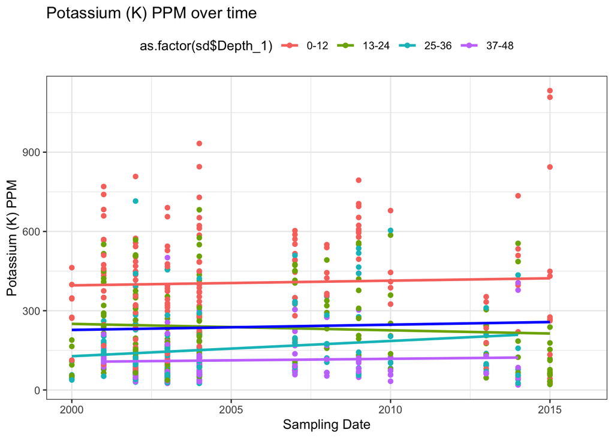

```r
ggplot(sd, aes(x=sd$Year, y=sd$ExchK_ppm, col=as.factor(sd$Depth_1))) +
            geom_point() + theme_bw() + theme(legend.position="top") +
            geom_smooth(se=FALSE, method="lm") +
            geom_smooth(aes(x=sd$Year, y=sd$ExchK_ppm), col="blue", se=FALSE, method='lm') +
            xlab("Sampling Date") +
            ylab("Potassium (K) PPM") +
            ggtitle("Potassium (K) PPM over time")
```

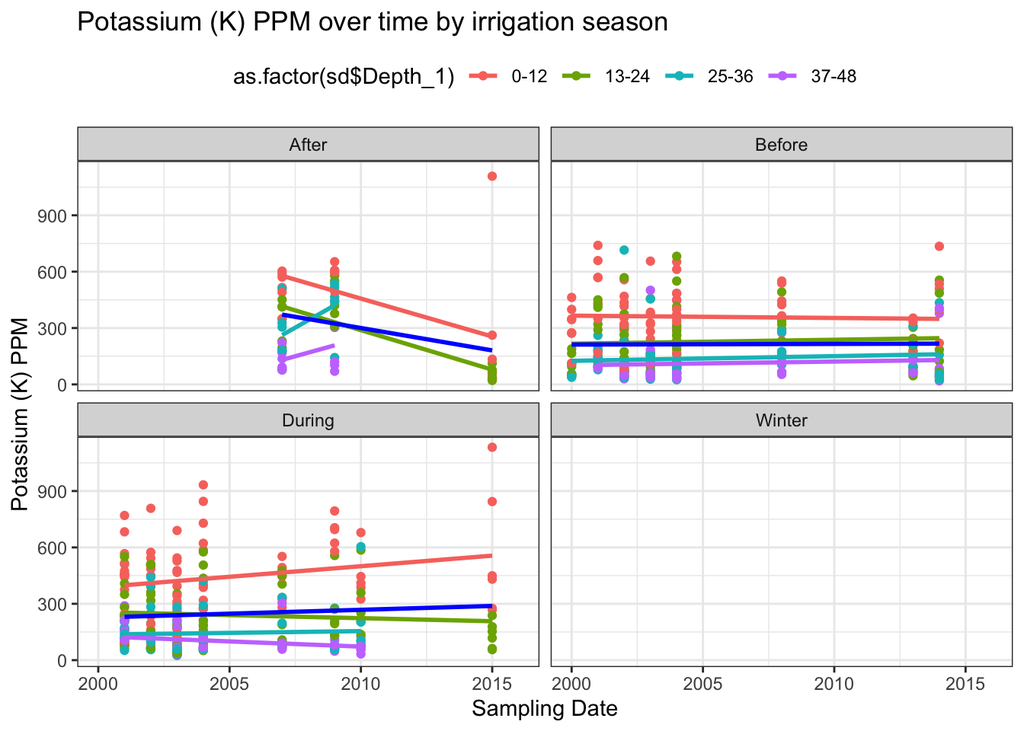

```r
## lets facet_wrap() by irrigation season
ggplot(sd, aes(x=sd$Year, y=sd$ExchK_ppm, col=as.factor(sd$Depth_1))) +
            geom_point() + theme_bw() + theme(legend.position="top") +
            geom_smooth(se=FALSE, method="lm") +
            geom_smooth(aes(x=sd$Year, y=sd$ExchK_ppm), col="blue", se=FALSE, method='lm') +
            facet_wrap(sd$Irr_season) +
            xlab("Sampling Date") +
            ylab("Potassium (K) PPM") +
            ggtitle("Potassium (K) PPM over time by irrigation season")
```

## Table of Sodium (Na) saturation percent (%)

```r
sd %>% group_by(Depth_1) %>%
 summarise(mean=mean(Na_Sat_pct, na.rm=TRUE),
           sd = sd(Na_Sat_pct, na.rm=TRUE),
              n = n()
              ) %>% kable
```

| Depth_1 | mean | sd | n |
| --- | --- | --- | --- |
| 0-12 | 13.72170 | 7.059188 | 226 |
| 13-24 | 17.16176 | 7.007266 | 226 |
| 25-36 | 19.24719 | 7.625827 | 204 |
| 37-48 | 20.03226 | 7.688260 | 172 |

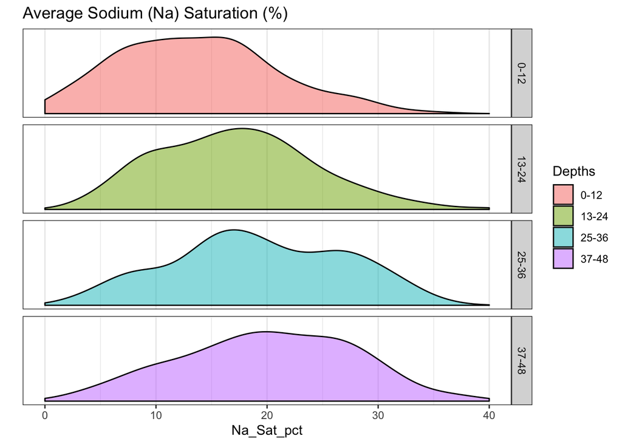

```r
ggplot(sd, aes(x=Na_Sat_pct, fill=Depth_1)) + ylab("") + geom_density(alpha=0.5) +
  facet_grid(Depth_1~.) +
  scale_y_continuous(breaks=NULL) +
  theme_bw() +
  labs(title="Average Sodium (Na) Saturation (%)") +
  scale_fill_discrete(name="Depths")
```

```r
aov(Na_Sat_pct~Depth_1, data=sd) %>% summary()
```

```
##              Df Sum Sq Mean Sq F value Pr(>F)
## Depth_1       3   4550  1516.7   28.33 <2e-16 ***
## Residuals   745  39878    53.5
## ---
## Signif. codes:  0 '***' 0.001 '**' 0.01 '*' 0.05 '.' 0.1 ' ' 1
## 79 observations deleted due to missingness
```

```r
TukeyHSD(aov(Na_Sat_pct~Depth_1, data=sd))
```

```
##   Tukey multiple comparisons of means
##     95% family-wise confidence level
##
## Fit: aov(formula = Na_Sat_pct ~ Depth_1, data = sd)
##
## $Depth_1
##                  diff        lwr      upr     p adj
## 13-24-0-12  3.4400666  1.5924862 5.287647 0.0000117
## 25-36-0-12  5.5254929  3.6103813 7.440604 0.0000000
## 37-48-0-12  6.3105600  4.3197080 8.301412 0.0000000
## 25-36-13-24 2.0854263  0.1532520 4.017601 0.0285303
## 37-48-13-24 2.8704934  0.8632224 4.877764 0.0014134
## 37-48-25-36 0.7850671 -1.2845308 2.854665 0.7627765
```

```r
summary(lm(Na_Sat_pct~Depth_1, data=sd))
```

```
##
## Call:
## lm(formula = Na_Sat_pct ~ Depth_1, data = sd)
##
## Residuals:
##      Min       1Q   Median       3Q      Max
## -18.0323  -5.2472  -0.1618   5.2783  22.8382
##
## Coefficients:
##              Estimate Std. Error t value Pr(>|t|)
## (Intercept)   13.7217     0.5025  27.308  < 2e-16 ***
## Depth_113-24   3.4401     0.7176   4.794 1.97e-06 ***
## Depth_125-36   5.5255     0.7438   7.429 3.00e-13 ***
## Depth_137-48   6.3106     0.7732   8.162 1.41e-15 ***
## ---
## Signif. codes:  0 '***' 0.001 '**' 0.01 '*' 0.05 '.' 0.1 ' ' 1
##
## Residual standard error: 7.316 on 745 degrees of freedom
##   (79 observations deleted due to missingness)
## Multiple R-squared:  0.1024, Adjusted R-squared:  0.0988
## F-statistic: 28.33 on 3 and 745 DF,  p-value: < 2.2e-16
```

```r
confint(lm(Na_Sat_pct~Depth_1, data=sd)) %>% kable()
```

|  | 2.5 % | 97.5 % |
| --- | --- | --- |
| (Intercept) | 12.735246 | 14.708150 |
| Depth_113-24 | 2.031402 | 4.848731 |
| Depth_125-36 | 4.065340 | 6.985646 |
| Depth_137-48 | 4.792660 | 7.828460 |